# MidtermTest_유학생분석

09_김세영 32_최윤정

2018년 11월 02일

[figure not shown]

출처 : https://post.naver.com/viewer/postView.nhn?volumeNo=9497662&memberNo=4644887

## **선정 데이터**

##### - 법무부_유학생관리정보 데이터 –> **법무부 국적 및 체류자격별 유학생 관련 현황 2017년 데이터**

##### - 출처 : [공공데이터포털](https://www.data.go.kr/dataset/3069982/fileData.do)

## **데이터 설명**

##### - 2017년 기준 유학생의 국적과 체류자격(비자)별 데이터를 담고 있음

##### - 체류자격은 크게 D-2와 D-4로 나뉨

##### - **한국유학비자 D-2** : 고등교육법 규정에 의해 설립된 전문대학, 대학, 대학원 또는 특별법 규정에 의해 설립된 전문대학 이상의 학술기관에서 정규과정의 교육을 받거나 특정의 연구를 하고자 할 때 받는 비자

- D-2-1 전문학사
- D-2-2 학사유학
- D-2-3 석사유학
- D-2-4 박사유학
- D-2-5 연구유학
- D-2-6 교환학생
- D-2-7 일-학습연계 유학
- D-2-8 단기유학

##### - **한국 어학연수비자 D-4** : 한국어 능력의 부족으로 유학(D-2)비자 발급에 어려움을 느끼는 외국인학생이 발급받는 비자

- D-4-1 대학부설어학원연수
- D-4-7 외국어연수

# **분석 과정**

## **1. 데이터 파악하기**

#### 데이터 불러오기

```r
student <- read.csv("법무부_국적_및_체류자격별_유학생_관련_현황_2017년_.csv")
```

#### 데이터 확인하기

```r
head(student)
```

```
##          국적명 성별 전문학사.D.2.1. 학사유학.D.2.2. 석사유학.D.2.3.
## 1 한국계 중국인   남               8             106              15
## 2 한국계 중국인   여               4              90              34
## 3    중      국   남             549          12,979           3,194
## 4    중      국   여             486          19,517           7,601
## 5    베  트  남   남             479           1,042             799
## 6    베  트  남   여             319           1,788             974
##   박사유학.D.2.4. 연구유학.D.2.5. 교환학생.D.2.6. 일.학습연계.유학.D.2.7.
## 1               8               1              16                       0
## 2              16               1              50                       0
## 3           1,305              37             924                       1
## 4           1,639              34           3,346                       5
## 5             548               5             112                       3
## 6             251               5             238                      11
##   단기유학.D.2.8. 대학부설어학원연수.D.4.1. 외국어연수.D.4.7.
## 1               0                        68                 0
## 2               0                        42                 0
## 3              58                     7,032                 0
## 4             143                     7,824                 0
## 5               3                    11,087                 0
## 6               9                     9,890                 0
```

```r
dim(student)
```

```
## [1] 354  12
```

```r
str(student)
```

```
## 'data.frame':    354 obs. of  12 variables:
##  $ 국적명                   : Factor w/ 177 levels "(마  카  오)",..: 176 176 129 129 59 59 156 156 115 115 ...
##  $ 성별                     : Factor w/ 2 levels "남","여": 1 2 1 2 1 2 1 2 1 2 ...
##  $ 전문학사.D.2.1.          : int  8 4 549 486 479 319 0 2 64 11 ...
##  $ 학사유학.D.2.2.          : Factor w/ 68 levels "0","1","1,042",..: 8 67 11 24 3 5 41 65 4 46 ...
##  $ 석사유학.D.2.3.          : Factor w/ 76 levels "0","1","1,410",..: 17 42 38 63 67 76 43 65 56 9 ...
##  $ 박사유학.D.2.4.          : Factor w/ 51 levels "0","1","1,305",..: 46 11 3 4 40 21 19 41 36 24 ...
##  $ 연구유학.D.2.5.          : int  1 1 37 34 5 5 3 3 0 0 ...
##  $ 교환학생.D.2.6.          : Factor w/ 64 levels "0","1","11","110",..: 14 48 62 30 5 23 61 44 46 7 ...
##  $ 일.학습연계.유학.D.2.7.  : int  0 0 1 5 3 11 2 14 5 7 ...
##  $ 단기유학.D.2.8.          : int  0 0 58 143 3 9 0 0 10 1 ...
##  $ 대학부설어학원연수.D.4.1.: Factor w/ 77 levels "0","1","1,681",..: 67 47 69 70 7 75 36 17 24 32 ...
##  $ 외국어연수.D.4.7.        : int  0 0 0 0 0 0 0 0 2 0 ...
```

#### 결측치는 존재하지 않음

```r
table(is.na(student))
```

```
##
## FALSE
##  4248
```

## **2. 데이터 전처리**

#### **1) 변수명 변경하기**

#### dplyr패키지를 설치하여 rename함수를 사용하여 변수 명을 변경함

```r
library(dplyr)

stu1 <- rename(student, nation = "국적명",
               gender = "성별",
               college = "전문학사.D.2.1.",
               univ = "학사유학.D.2.2.",
               master = "석사유학.D.2.3.",
               doctorate = "박사유학.D.2.4.",
               research = "연구유학.D.2.5.",
               exchange = "교환학생.D.2.6.",
               jobstudy = "일.학습연계.유학.D.2.7.",
               short = "단기유학.D.2.8.",
               language = "대학부설어학원연수.D.4.1.",
               foreignLang = "외국어연수.D.4.7.")
head(stu1)
```

```
##          nation gender college   univ master doctorate research exchange
## 1 한국계 중국인     남       8    106     15         8        1       16
## 2 한국계 중국인     여       4     90     34        16        1       50
## 3    중      국     남     549 12,979  3,194     1,305       37      924
## 4    중      국     여     486 19,517  7,601     1,639       34    3,346
## 5    베  트  남     남     479  1,042    799       548        5      112
## 6    베  트  남     여     319  1,788    974       251        5      238
##   jobstudy short language foreignLang
## 1        0     0       68           0
## 2        0     0       42           0
## 3        1    58    7,032           0
## 4        5   143    7,824           0
## 5        3     3   11,087           0
## 6       11     9    9,890           0
```

```r
str(stu1)
```

```
## 'data.frame':    354 obs. of  12 variables:
##  $ nation     : Factor w/ 177 levels "(마  카  오)",..: 176 176 129 129 59 59 156 156 115 115 ...
##  $ gender     : Factor w/ 2 levels "남","여": 1 2 1 2 1 2 1 2 1 2 ...
##  $ college    : int  8 4 549 486 479 319 0 2 64 11 ...
##  $ univ       : Factor w/ 68 levels "0","1","1,042",..: 8 67 11 24 3 5 41 65 4 46 ...
##  $ master     : Factor w/ 76 levels "0","1","1,410",..: 17 42 38 63 67 76 43 65 56 9 ...
##  $ doctorate  : Factor w/ 51 levels "0","1","1,305",..: 46 11 3 4 40 21 19 41 36 24 ...
##  $ research   : int  1 1 37 34 5 5 3 3 0 0 ...
##  $ exchange   : Factor w/ 64 levels "0","1","11","110",..: 14 48 62 30 5 23 61 44 46 7 ...
##  $ jobstudy   : int  0 0 1 5 3 11 2 14 5 7 ...
##  $ short      : int  0 0 58 143 3 9 0 0 10 1 ...
##  $ language   : Factor w/ 77 levels "0","1","1,681",..: 67 47 69 70 7 75 36 17 24 32 ...
##  $ foreignLang: int  0 0 0 0 0 0 0 0 2 0 ...
```

#### **2) factor형을 numeric으로 변경하기**

```r
library(dplyr)

stu2 <- stu1 %>% mutate(univ = as.numeric(gsub(",","",univ)),
                        master = as.numeric(gsub(",","",master)),
                        doctorate = as.numeric(gsub(",","",doctorate)),
                        exchange = as.numeric(gsub(",","",exchange)),
                        language = as.numeric(gsub(",","",language)))

str(stu2)
```

```
## 'data.frame':    354 obs. of  12 variables:
##  $ nation     : Factor w/ 177 levels "(마  카  오)",..: 176 176 129 129 59 59 156 156 115 115 ...
##  $ gender     : Factor w/ 2 levels "남","여": 1 2 1 2 1 2 1 2 1 2 ...
##  $ college    : int  8 4 549 486 479 319 0 2 64 11 ...
##  $ univ       : num  106 90 12979 19517 1042 ...
##  $ master     : num  15 34 3194 7601 799 ...
##  $ doctorate  : num  8 16 1305 1639 548 ...
##  $ research   : int  1 1 37 34 5 5 3 3 0 0 ...
##  $ exchange   : num  16 50 924 3346 112 ...
##  $ jobstudy   : int  0 0 1 5 3 11 2 14 5 7 ...
##  $ short      : int  0 0 58 143 3 9 0 0 10 1 ...
##  $ language   : num  68 42 7032 7824 11087 ...
##  $ foreignLang: int  0 0 0 0 0 0 0 0 2 0 ...
```

# **분석에 사용할 최종 데이터 : stu2**

## **3. 데이터 분석 시작**

### **1) 기본통계**

#### 기본 통계량 살펴보기

```r
summary(stu2)
```

```
##            nation    gender      college             univ
##  (마  카  오) :  2   남:177   Min.   :  0.000   Min.   :    0.0
##  (영국 외지민):  2   여:177   1st Qu.:  0.000   1st Qu.:    0.0
##  (타  이  완) :  2            Median :  0.000   Median :    2.0
##  (홍      콩) :  2            Mean   :  6.517   Mean   :  124.8
##  가      나   :  2            3rd Qu.:  0.000   3rd Qu.:   10.0
##  가      봉   :  2            Max.   :549.000   Max.   :19517.0
##  (Other)      :342
##      master          doctorate          research          exchange
##  Min.   :   0.00   Min.   :   0.00   Min.   : 0.0000   Min.   :   0.00
##  1st Qu.:   1.00   1st Qu.:   0.00   1st Qu.: 0.0000   1st Qu.:   0.00
##  Median :   4.00   Median :   1.00   Median : 0.0000   Median :   0.00
##  Mean   :  60.58   Mean   :  21.32   Mean   : 0.4265   Mean   :  28.60
##  3rd Qu.:  15.00   3rd Qu.:   4.00   3rd Qu.: 0.0000   3rd Qu.:   5.75
##  Max.   :7601.00   Max.   :1639.00   Max.   :37.0000   Max.   :3346.00
##
##     jobstudy          short            language        foreignLang
##  Min.   : 0.000   Min.   :  0.000   Min.   :    0.0   Min.   :0.0000
##  1st Qu.: 0.000   1st Qu.:  0.000   1st Qu.:    0.0   1st Qu.:0.0000
##  Median : 0.000   Median :  0.000   Median :    2.0   Median :0.0000
##  Mean   : 1.551   Mean   :  1.613   Mean   :  136.2   Mean   :0.0113
##  3rd Qu.: 2.000   3rd Qu.:  0.000   3rd Qu.:    9.0   3rd Qu.:0.0000
##  Max.   :15.000   Max.   :143.000   Max.   :11087.0   Max.   :2.0000
##
```

#### 기본통계기법을 사용하여 **학사유학생**(4년제 대학교로 유학을 온 것)과 **교환학생**(본 국가에서 대학을 다니고 있는데, 한국의 대학으로 교환학생 온 학생)의 수를 비교하기

```r
#학사유학생
min(stu2$univ); max(stu2$univ) ; mean(stu2$univ);sd(stu2$univ)
```

```
## [1] 0
```

```
## [1] 19517
```

```
## [1] 124.8079
```

```
## [1] 1249.754
```

```r
#교환학생
min(stu2$exchange);max(stu2$exchange);mean(stu2$exchange);sd(stu2$exchange)
```

```
## [1] 0
```

```
## [1] 3346
```

```
## [1] 28.59605
```

```
## [1] 191.9612
```

#### 학사유학생이 교환학생보다 최댓값, 평균, 표준편차가 모두 큰것을 볼 수 있음

### **2) 성별 유학생 현황**

#### 성별로 비자별 유학생 수를 모두 더한 총유학생 수를 구하기

```r
library(dplyr)

gender <- stu2 %>%
  group_by(gender) %>%
  summarise(a = sum(college),
            b = sum(univ),
            c = sum(master),
            d = sum(doctorate),
            e = sum(research),
            f = sum(exchange),
            g = sum(jobstudy),
            h = sum(short),
            i = sum(language),
            j = sum(foreignLang)) %>%
  mutate(sumgender = a+b+c+d+e+f+g+h+i+j)

gen_all <- gender$sumgender
```

#### row명 삽입하기

```r
gen_a <- data.frame(gen_all, row.names = c("male", "female"))

gen_a
```

```
##        gen_all
## male     60293
## female   74794
```

#### 행렬 전환하는 함수 transepose를 사용하여 그래프로 표현하기

```r
gen_a <- t(gen_a)
gen_a
```

```
##          male female
## gen_all 60293  74794
```

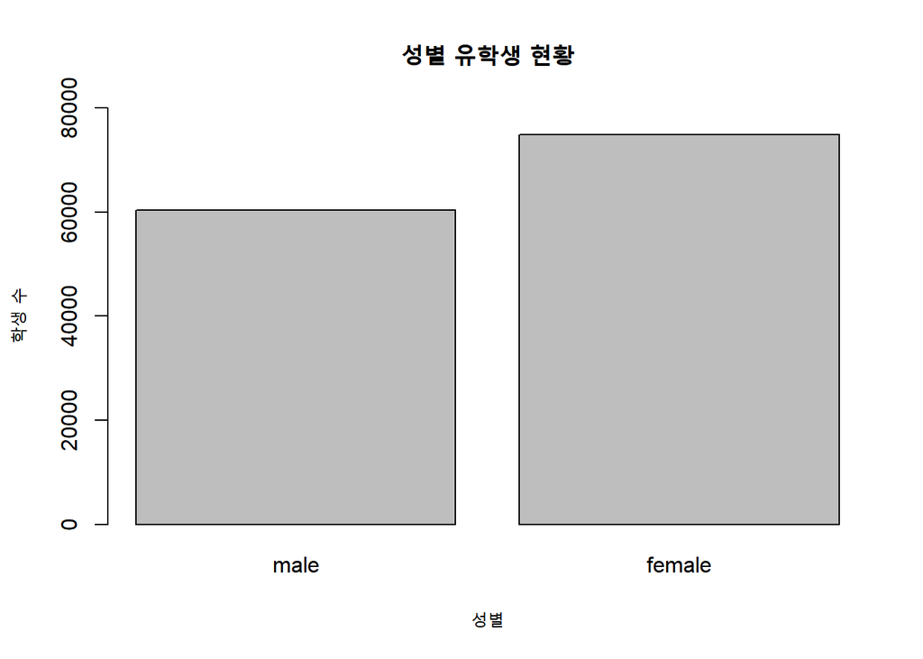

```r
barplot(gen_a,ylim=c(0,80000), main='성별 유학생 현황', xlab='성별', ylab='학생 수', col='gray')
```

#### 여학생이 남학생보다 약 1만4천명정도 더 많은 것으로 나타남

### **3) 국가별 남녀 유학생 현황**

#### 국가, 성별로 그룹을 만든 뒤 비자별 유학생 수를 모두 더한 총유학생 수를 구하기

```r
library(dplyr)

data <- stu2 %>%
  group_by(nation, gender) %>%
  mutate(sum_all = sum(college+univ+master+doctorate+research+exchange+jobstudy+short+language+foreignLang)) %>% select(nation, gender, sum_all) %>%
  arrange(desc(sum_all)) %>%
  head(30)

data
```

```
## # A tibble: 30 x 3
## # Groups:   nation, gender [30]
##    nation       gender sum_all
##    <fct>        <fct>    <dbl>
##  1 중      국   여       40595
##  2 중      국   남       26079
##  3 베  트  남   남       14078
##  4 베  트  남   여       13485
##  5 몽      골   여        5022
##  6 우즈베키스탄 남        4038
##  7 몽      골   남        2762
##  8 일      본   여        2057
##  9 파 키 스 탄  남        1259
## 10 (타  이  완) 여        1065
## # ... with 20 more rows
```

#### 그래프로 표현하기

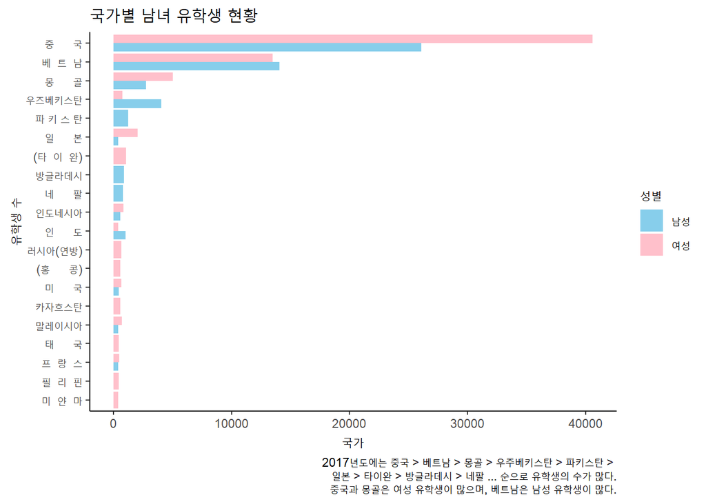

```r
library(ggplot2)

ggplot(data = data, aes(x=reorder(nation, sum_all), y=sum_all, fill = gender)) + geom_col(position = "dodge") + coord_flip() + labs(title='국가별 남녀 유학생 현황', x='유학생 수', y='국가', caption='2017년도에는 중국 > 베트남 > 몽골 > 우주베키스탄 > 파키스탄 >
        일본 > 타이완 > 방글라데시 > 네팔 ... 순으로 유학생의 수가 많다.
                                                                                                                                   중국과 몽골은 여성 유학생이 많으며, 베트남은 남성 유학생이 많다.') + scale_fill_manual(values = c("sky blue", "pink"), name="성별", labels=c("남성", "여성")) + theme_classic()
```

#### - 중국, 베트남, 몽골순으로 유학생의 수가 많음

#### - 중국과 몽골은 여성 유학생이 많고, 베트남은 남성 유학생이 더 많음

### **4) 비자유형별 남녀 유학생 현황**

#### 성별로 비자별 유학생수 합계를 구하기

```r
library(dplyr)

a <- stu2 %>%
  group_by(gender) %>%
  summarise(a = sum(college),
            b = sum(univ),
            c = sum(master),
            d = sum(doctorate),
            e = sum(research),
            f = sum(exchange),
            g = sum(jobstudy),
            h = sum(short),
            i = sum(language),
            j = sum(foreignLang)) %>%
  select(-gender)

a
```

```
## # A tibble: 2 x 10
##       a     b     c     d     e     f     g     h     i     j
##   <int> <dbl> <dbl> <dbl> <int> <dbl> <int> <int> <dbl> <int>
## 1  1263 18495  8716  4479    88  2760   185   189 24114     4
## 2  1044 25687 12728  3069    63  7363   364   382 24094     0
```

#### row명 삽입하기

```r
rownames(a) <- c("male","female")
a
```

```
## # A tibble: 2 x 10
##       a     b     c     d     e     f     g     h     i     j
## * <int> <dbl> <dbl> <dbl> <int> <dbl> <int> <int> <dbl> <int>
## 1  1263 18495  8716  4479    88  2760   185   189 24114     4
## 2  1044 25687 12728  3069    63  7363   364   382 24094     0
```

#### 행렬 전환하는 함수 transepose를 사용하여 그래프로 표현하기

```r
b <- t(a)

b
```

```
##    male female
## a  1263   1044
## b 18495  25687
## c  8716  12728
## d  4479   3069
## e    88     63
## f  2760   7363
## g   185    364
## h   189    382
## i 24114  24094
## j     4      0
```

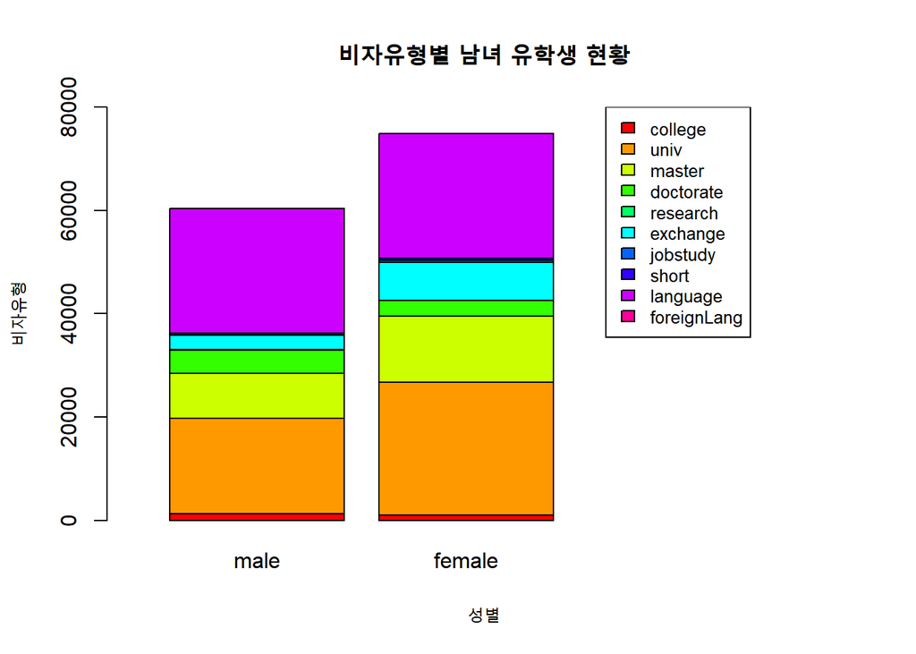

```r
barplot(b,col=rainbow(10), main ="비자유형별 남녀 유학생 현황" , xlab="성별", ylab="비자유형", ylim=c(0,80000), xlim=c(0,4))

legend(2.7,80000 ,c("college","univ","master","doctorate","research","exchange","jobstudy","short","language","foreignLang"),cex=0.8, fill=rainbow(nrow(b)))
```

### **5) 체류자격별(D2 vs D4) 남녀 유학생 현황**

##### - 체류자격을 한국유학비자(D-2)와 한국 어학연수비자(D-4)로 구분하여 유학생 수를 비교하기

##### - 각 체류자격별, 성별로 어떤 국가의 유학생수가 많은지 파악하기

##### - 국가, 성별로 그룹화 한 뒤 여성데이터와 남성 데이터에서로 각각 나누기

#### -각 성별로 기존의 비자에서 D2와 D4 체류자격으로 새로운 변수를 생성하여 체류자격별 유학생 수를 구하기

#### - 상위 10개의 국가만 추출하여 그래프로 표현하기

```r
library(dplyr)

f_d2 <- stu2 %>%
  group_by(nation, gender) %>%
  filter(gender == '여') %>%
  mutate(D2 = sum(college:short)) %>%
  select(nation, gender, D2) %>%
  arrange(desc(D2)) %>%
  head(10)

f_d2
```

```
## # A tibble: 10 x 3
## # Groups:   nation, gender [10]
##    nation       gender     D2
##    <fct>        <fct>   <int>
##  1 중      국   여     108188
##  2 베  트  남   여      51004
##  3 미      국   여       4494
##  4 싱 가 포 르  여       2556
##  5 몽      골   여       1891
##  6 일      본   여        735
##  7 말레이시아   여        363
##  8 러시아(연방) 여        120
##  9 인도네시아   여         84
## 10 우즈베키스탄 여         66
```

```r
f_d4 <- stu2 %>%
  group_by(nation, gender) %>%
  filter(gender == '여') %>%
  mutate(D4 = sum(language, foreignLang)) %>%
  select(nation, gender, D4) %>%
  arrange(desc(D4)) %>%
  head(10)

f_d4
```

```
## # A tibble: 10 x 3
## # Groups:   nation, gender [10]
##    nation       gender    D4
##    <fct>        <fct>  <dbl>
##  1 베  트  남   여      9890
##  2 중      국   여      7824
##  3 몽      골   여      2591
##  4 일      본   여       661
##  5 (타  이  완) 여       333
##  6 (홍      콩) 여       257
##  7 우즈베키스탄 여       235
##  8 러시아(연방) 여       231
##  9 태      국   여       152
## 10 인도네시아   여       141
```

```r
m_d2 <- stu2 %>%
  group_by(nation, gender) %>%
  filter(gender == '남') %>%
  mutate(D2 = sum(college:short)) %>%
  select(nation, gender, D2) %>%
  arrange(desc(D2)) %>%
  head(10)

m_d2
```

```
## # A tibble: 10 x 3
## # Groups:   nation, gender [10]
##    nation        gender     D2
##    <fct>         <fct>   <int>
##  1 중      국    남     149322
##  2 베  트  남    남     114957
##  3 우즈베키스탄  남       2035
##  4 싱 가 포 르   남        595
##  5 말레이시아    남        594
##  6 몽      골    남        465
##  7 미      국    남        455
##  8 스 리 랑 카   남        300
##  9 인      도    남         68
## 10 한국계 중국인 남         36
```

```r
m_d4 <- stu2 %>%
  group_by(nation, gender) %>%
  filter(gender == '남') %>%
  mutate(D4 = sum(language, foreignLang)) %>%
  select(nation, gender, D4) %>%
  arrange(desc(D4)) %>%
  head(10)

m_d4
```

```
## # A tibble: 10 x 3
## # Groups:   nation, gender [10]
##    nation       gender    D4
##    <fct>        <fct>  <dbl>
##  1 베  트  남   남     11087
##  2 중      국   남      7032
##  3 우즈베키스탄 남      2170
##  4 몽      골   남      1681
##  5 인      도   남       202
##  6 스 리 랑 카  남       162
##  7 네      팔   남       139
##  8 일      본   남       100
##  9 미  얀  마   남        91
## 10 파 키 스 탄  남        70
```

#### 그래프로 표현하기

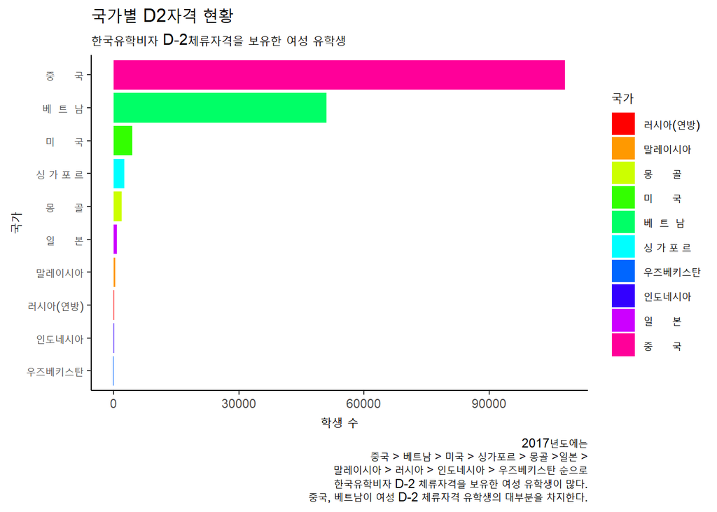

```r
library(ggplot2)

ggplot(data = f_d2, aes(x=reorder(nation, D2), y=D2, fill = visa)) + geom_col(position = "dodge", aes(fill = nation)) + coord_flip() + labs(title = '국가별 D2자격 현황', x='국가', y='학생 수', subtitle='한국유학비자 D-2체류자격을 보유한 여성 유학생', caption='2017년도에는
               중국 > 베트남 > 미국 > 싱가포르 > 몽골 >일본 >
                말레이시아 > 러시아 > 인도네시아 > 우즈베키스탄 순으로
              한국유학비자 D-2 체류자격을 보유한 여성 유학생이 많다.
              중국, 베트남이 여성 D-2 체류자격 유학생의 대부분을 차지한다.') + scale_fill_manual(values=rainbow(10), name="국가") + theme_classic()
```

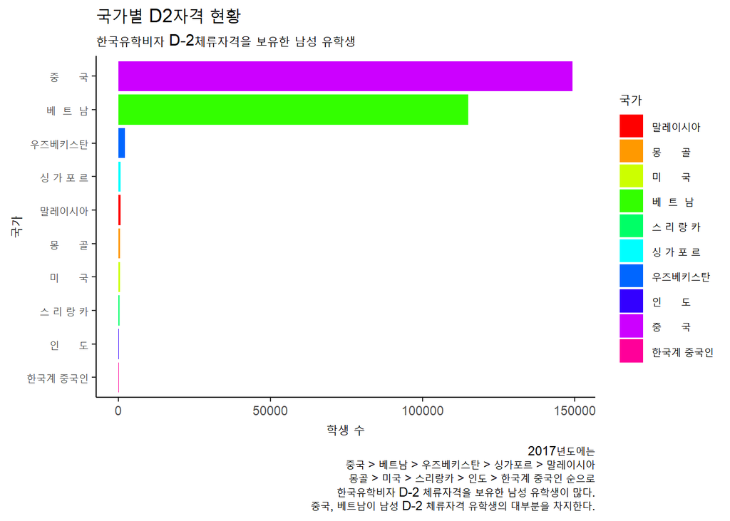

```r
ggplot(data = m_d2, aes(x=reorder(nation,  D2), y=D2)) + geom_col(position = "dodge", aes(fill = nation)) + coord_flip() + labs(title = '국가별 D2자격 현황', x='국가', y='학생 수', subtitle='한국유학비자 D-2체류자격을 보유한 남성 유학생', caption='2017년도에는
중국 > 베트남 > 우즈베키스탄 > 싱가포르 > 말레이시아
몽골 > 미국 > 스리랑카 > 인도 > 한국계 중국인 순으로
한국유학비자 D-2 체류자격을 보유한 남성 유학생이 많다.
중국, 베트남이 남성 D-2 체류자격 유학생의 대부분을 차지한다.') + scale_fill_manual(values=rainbow(10), name="국가") + theme_classic()
```

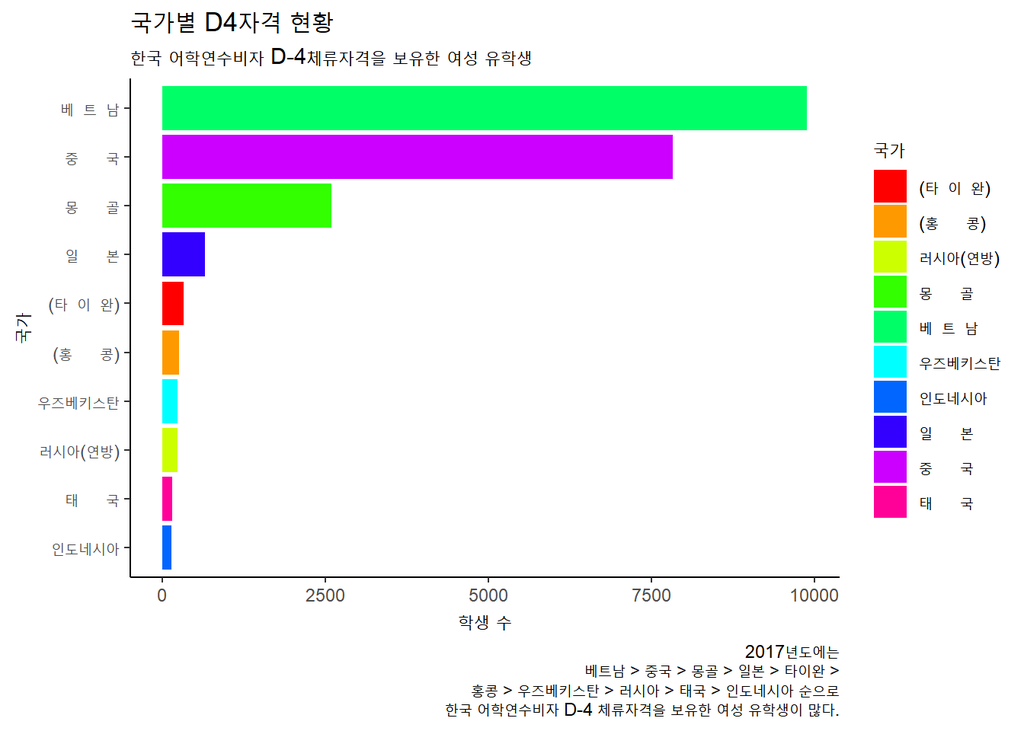

```r
ggplot(data = f_d4, aes(x=reorder(nation, D4), y=D4)) + geom_col(position = "dodge", aes(fill = nation)) + coord_flip()  + labs(title = '국가별 D4자격 현황', x='국가', y='학생 수', subtitle='한국 어학연수비자 D-4체류자격을 보유한 여성 유학생', caption='2017년도에는
베트남 > 중국 > 몽골 > 일본 > 타이완 >
홍콩 > 우즈베키스탄 > 러시아 > 태국 > 인도네시아 순으로
한국 어학연수비자 D-4 체류자격을 보유한 여성 유학생이 많다.') + scale_fill_manual(values=rainbow(10), name="국가") + theme_classic()
```

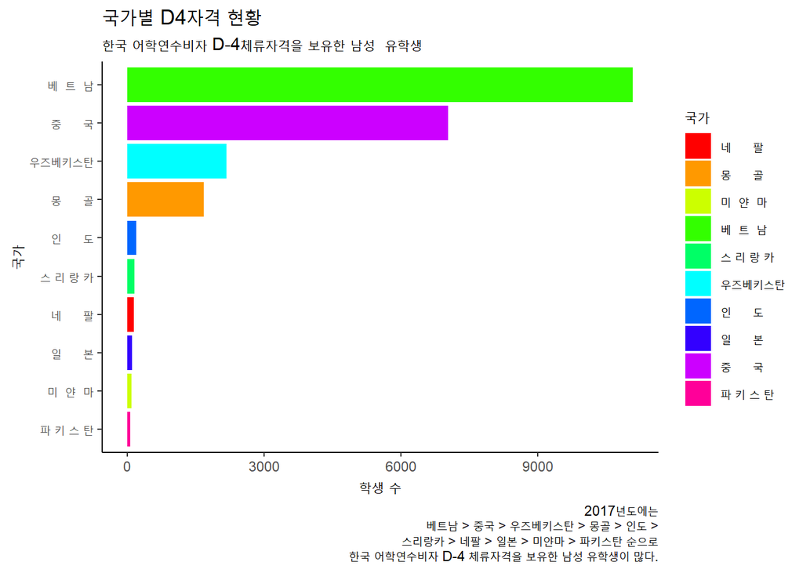

```r
ggplot(data = m_d4, aes(x=reorder(nation, D4), y=D4)) + geom_col(position = "dodge", aes(fill = nation)) + coord_flip() + labs(title = '국가별 D4자격 현황', x='국가', y='학생 수', subtitle='한국 어학연수비자 D-4체류자격을 보유한 남성  유학생', caption='2017년도에는
베트남 > 중국 > 우즈베키스탄 > 몽골 > 인도 >
스리랑카 > 네팔 > 일본 > 미얀마 > 파키스탄 순으로
한국 어학연수비자 D-4 체류자격을 보유한 남성 유학생이 많다.') + scale_fill_manual(values=rainbow(10), name="국가") + theme_classic()
```

#### **그래프 한 번에 보기**

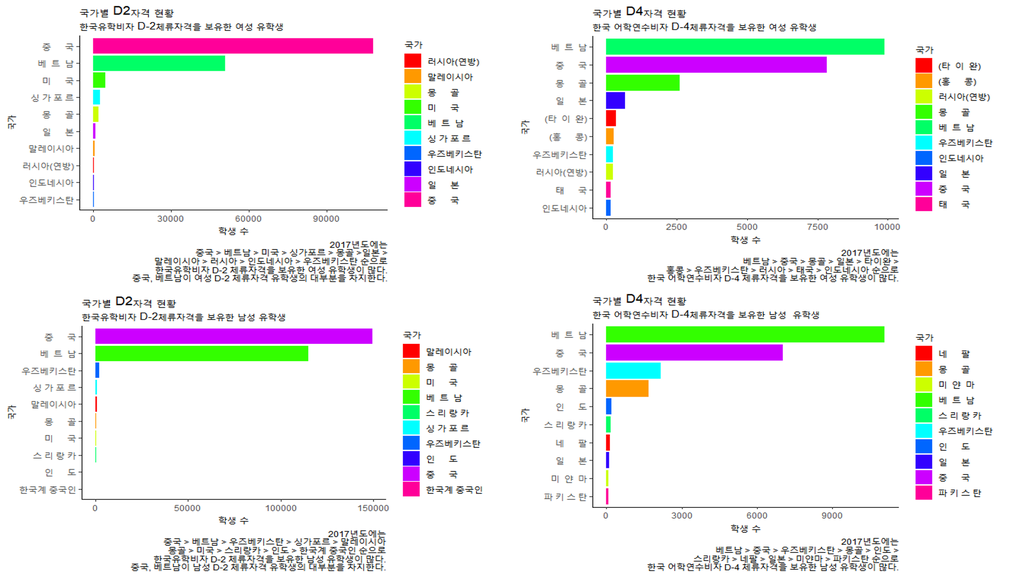

#### - 한국유학비자(D2)체류자격은 남녀 유학생 모두 중국 > 베트남 순으로 유학생 수가 많음

#### - 한국 어학연수비자(D4)체류자격에서 여성 유학생은 베트남 > 중국 > 몽골 > 일본 순으로 많고, 남성유학생은 베트남 > 중국 > 우즈베키스탄 > 몽골 순으로 유학생이 대부분을 차지함

#### - 체류자격, 성별 상관없이 중국, 베트남은 항상 유학생 수가 많은 것으로 나타남

### **6) 15,16,17년도 비자 유형별 유학생 수 변화**

#### 앞에서 다룬 2017년 유학생 데이터와 함께 ’2016년 유학생 데이터’와 ’2015년 유학생 데이터’의 국가별 유학생 비자 유형추출하기

#### 앞에서 다룬 2017년 유학생 데이터 다시 한 번 살펴보기

```r
head(stu2)
```

```
##          nation gender college  univ master doctorate research exchange
## 1 한국계 중국인     남       8   106     15         8        1       16
## 2 한국계 중국인     여       4    90     34        16        1       50
## 3    중      국     남     549 12979   3194      1305       37      924
## 4    중      국     여     486 19517   7601      1639       34     3346
## 5    베  트  남     남     479  1042    799       548        5      112
## 6    베  트  남     여     319  1788    974       251        5      238
##   jobstudy short language foreignLang
## 1        0     0       68           0
## 2        0     0       42           0
## 3        1    58     7032           0
## 4        5   143     7824           0
## 5        3     3    11087           0
## 6       11     9     9890           0
```

```r
str(stu2)
```

```
## 'data.frame':    354 obs. of  12 variables:
##  $ nation     : Factor w/ 177 levels "(마  카  오)",..: 176 176 129 129 59 59 156 156 115 115 ...
##  $ gender     : Factor w/ 2 levels "남","여": 1 2 1 2 1 2 1 2 1 2 ...
##  $ college    : int  8 4 549 486 479 319 0 2 64 11 ...
##  $ univ       : num  106 90 12979 19517 1042 ...
##  $ master     : num  15 34 3194 7601 799 ...
##  $ doctorate  : num  8 16 1305 1639 548 ...
##  $ research   : int  1 1 37 34 5 5 3 3 0 0 ...
##  $ exchange   : num  16 50 924 3346 112 ...
##  $ jobstudy   : int  0 0 1 5 3 11 2 14 5 7 ...
##  $ short      : int  0 0 58 143 3 9 0 0 10 1 ...
##  $ language   : num  68 42 7032 7824 11087 ...
##  $ foreignLang: int  0 0 0 0 0 0 0 0 2 0 ...
```

```r
stu2017 <- stu2 %>%
  select(nation, univ,master,doctorate,research,exchange,language,foreignLang) %>%
  group_by(nation) %>%
  summarise(un = sum(univ), ma = sum(master), do= sum(doctorate),re=sum(research),ex= sum(exchange), la=sum(language),fo=sum(foreignLang))

str(stu2017)
```

```
## Classes 'tbl_df', 'tbl' and 'data.frame':    177 obs. of  8 variables:
##  $ nation: Factor w/ 177 levels "(마  카  오)",..: 1 2 3 4 5 6 7 8 9 10 ...
##  $ un    : num  29 0 121 265 23 11 0 3 7 0 ...
##  $ ma    : num  3 1 144 30 232 9 3 4 13 3 ...
##  $ do    : num  0 0 21 2 53 2 0 1 9 0 ...
##  $ re    : int  0 0 1 1 0 0 0 0 0 0 ...
##  $ ex    : num  9 0 551 76 0 0 0 0 2 2 ...
##  $ la    : num  23 0 365 295 42 4 0 4 5 1 ...
##  $ fo    : int  0 0 0 0 0 0 0 0 0 0 ...
```

## 2016년 데이터 불러오기

```r
stu16 <- read.csv("유학생관련_현황.csv")
head(stu16)
```

```
##          국적명 유학.D.2. 전문학사.D.2.1. 학사유학.D.2.2. 석사유학.D.2.3.
## 1 한국계 중국인        95               5              63              17
## 2 한국계 중국인        73               4              50              11
## 3    중      국    17,111             537          11,347           3,013
## 4    중      국    29,425             490          16,371           6,773
## 5    베  트  남     2,300             268             680             756
## 6    베  트  남     2,392             162           1,025             796
##   박사유학.D.2.4. 연구유학.D.2.5. 교환학생.D.2.6. 일.학습연계.유학.D.2
## 1               9               1               0                    0
## 2               8               0               0                    0
## 3           1,044              24           1,127                    2
## 4           1,326              17           4,378                    4
## 5             536               7              51                    0
## 6             234               4             166                    4
##   단기유학.D.2.8. 교환학생.D.2.F. 일반연수.D.4. 대학부설어학원연수.D
## 1               0               0             8                    8
## 2               0               0             4                    4
## 3              16               1         8,793                8,793
## 4              66               0        11,105               11,105
## 5               2               0         5,311                5,311
## 6               1               0         5,190                5,190
##   외국어연수.D.4.7.
## 1                 0
## 2                 0
## 3                 0
## 4                 0
## 5                 0
## 6                 0
```

```r
str(stu16)
```

```
## 'data.frame':    414 obs. of  14 variables:
##  $ 국적명              : Factor w/ 207 levels "가      나","가      봉",..: 204 204 152 152 68 68 179 179 202 202 ...
##  $ 유학.D.2.           : Factor w/ 119 levels "0","1","1,022",..: 114 105 27 49 31 32 11 57 34 60 ...
##  $ 전문학사.D.2.1.     : int  5 4 537 490 268 162 0 3 1 4 ...
##  $ 학사유학.D.2.2.     : Factor w/ 64 levels "0","1","1,025",..: 54 47 6 13 56 3 34 61 40 49 ...
##  $ 석사유학.D.2.3.     : Factor w/ 73 levels "0","1","10","100",..: 19 7 38 60 64 66 49 5 6 22 ...
##  $ 박사유학.D.2.4.     : Factor w/ 51 levels "0","1","1,044",..: 50 47 3 4 41 22 27 42 35 44 ...
##  $ 연구유학.D.2.5.     : int  1 0 24 17 7 4 1 4 1 1 ...
##  $ 교환학생.D.2.6.     : Factor w/ 63 levels "0","1","1,127",..: 1 1 3 36 46 14 59 50 62 29 ...
##  $ 일.학습연계.유학.D.2: int  0 0 2 4 0 4 0 3 1 2 ...
##  $ 단기유학.D.2.8.     : int  0 0 16 66 2 1 3 24 0 1 ...
##  $ 교환학생.D.2.F.     : int  0 0 1 0 0 0 0 0 0 0 ...
##  $ 일반연수.D.4.       : Factor w/ 70 levels "0","1","1,145",..: 63 42 64 5 51 50 31 7 45 65 ...
##  $ 대학부설어학원연수.D: Factor w/ 69 levels "0","1","1,145",..: 62 41 63 5 50 49 30 7 44 64 ...
##  $ 외국어연수.D.4.7.   : int  0 0 0 0 0 0 0 0 0 0 ...
```

#### 변수명과 데이터 타입 변경하기

```r
stu016 <- rename(stu16, nation = '국적명',
                 univ = '학사유학.D.2.2.',
                 master = '석사유학.D.2.3.',
                 doctorate = '박사유학.D.2.4.',
                 research = '연구유학.D.2.5.',
                 exchange = '교환학생.D.2.6.',
                 language = '대학부설어학원연수.D',
                 foreignLang = '외국어연수.D.4.7.')

stu0016 <- stu016 %>% mutate(univ = as.numeric(gsub(",","",univ)),
                             master = as.numeric(gsub(",","",master)),
                             doctorate = as.numeric(gsub(",","",doctorate)),
                             exchange = as.numeric(gsub(",","",exchange)),
                             language = as.numeric(gsub(",","",language)))

str(stu0016)
```

```
## 'data.frame':    414 obs. of  14 variables:
##  $ nation              : Factor w/ 207 levels "가      나","가      봉",..: 204 204 152 152 68 68 179 179 202 202 ...
##  $ 유학.D.2.           : Factor w/ 119 levels "0","1","1,022",..: 114 105 27 49 31 32 11 57 34 60 ...
##  $ 전문학사.D.2.1.     : int  5 4 537 490 268 162 0 3 1 4 ...
##  $ univ                : num  63 50 11347 16371 680 ...
##  $ master              : num  17 11 3013 6773 756 ...
##  $ doctorate           : num  9 8 1044 1326 536 ...
##  $ research            : int  1 0 24 17 7 4 1 4 1 1 ...
##  $ exchange            : num  0 0 1127 4378 51 ...
##  $ 일.학습연계.유학.D.2: int  0 0 2 4 0 4 0 3 1 2 ...
##  $ 단기유학.D.2.8.     : int  0 0 16 66 2 1 3 24 0 1 ...
##  $ 교환학생.D.2.F.     : int  0 0 1 0 0 0 0 0 0 0 ...
##  $ 일반연수.D.4.       : Factor w/ 70 levels "0","1","1,145",..: 63 42 64 5 51 50 31 7 45 65 ...
##  $ language            : num  8 4 8793 11105 5311 ...
##  $ foreignLang         : int  0 0 0 0 0 0 0 0 0 0 ...
```

#### 다른 데이터와 공통적으로 나타나는비자 7개를 추출하여 비자별 유학생 수 합계구하기

```r
stu2016 <- stu0016 %>%
  select(nation, univ,master,doctorate,research,exchange, language, foreignLang) %>%
  group_by(nation) %>%
  summarise(un = sum(univ), ma = sum(master), do= sum(doctorate),re=sum(research),ex= sum(exchange), la=sum(language),fo=sum(foreignLang))

head(stu2016)
```

```
## # A tibble: 6 x 8
##   nation         un    ma    do    re    ex    la    fo
##   <fct>       <dbl> <dbl> <dbl> <int> <dbl> <dbl> <int>
## 1 가      나     20   123    47     0     1    24     0
## 2 가      봉     10    10     3     0     0     8     0
## 3 가 이 아 나     0     1     0     0     0     0     0
## 4 감  비  아      2     4     1     0     0     2     0
## 5 과 테 말 라    10    18     9     0     0     3     0
## 6 교황청          0     0     0     0     0     0     0
```

```r
str(stu2016)
```

```
## Classes 'tbl_df', 'tbl' and 'data.frame':    207 obs. of  8 variables:
##  $ nation: Factor w/ 207 levels "가      나","가      봉",..: 1 2 3 4 5 6 7 8 9 10 ...
##  $ un    : num  20 10 0 2 10 0 0 0 0 0 ...
##  $ ma    : num  123 10 1 4 18 0 0 3 0 0 ...
##  $ do    : num  47 3 0 1 9 0 0 0 0 0 ...
##  $ re    : int  0 0 0 0 0 0 0 0 0 0 ...
##  $ ex    : num  1 0 0 0 0 0 0 1 0 0 ...
##  $ la    : num  24 8 0 2 3 0 0 2 0 16 ...
##  $ fo    : int  0 0 0 0 0 0 0 1 0 0 ...
```

## 2015데이터 불러오기

```r
stu15 <- read.csv("_2015년_국적_및_체류자격별_유학생_통계_자료.csv")
head(stu15)
```

```
##    국적.및.지역 성별   합계 유학.D.2. 전문학사.D.2.1. 학사유학.D.2.2.
## 1    중      국  (M) 24,034    15,824             679          10,098
## 2    중      국  (F) 34,752    24,678             592          13,323
## 3 한국계 중국인  (M)    210       191              46             112
## 4 한국계 중국인  (F)    196       182              38             112
## 5    베  트  남  (M)  3,649     1,830             164             436
## 6    베  트  남  (F)  3,796     1,663              88             619
##   석사유학.D.2.3. 박사유학.D.2.4. 연구유학.D.2.5. 교환학생.D.2.6.
## 1           3,154             905              16             971
## 2           5,861           1,179               8           3,715
## 3              21              12               0               0
## 4              21              11               0               0
## 5             707             489               1              33
## 6             646             202               0             108
##   교환학생.D.2.F. 일반연수.D.4. 대학부설어학원연수.D.4.1.
## 1               1         8,210                     8,210
## 2               0        10,074                    10,074
## 3               0            19                        19
## 4               0            14                        14
## 5               0         1,819                     1,819
## 6               0         2,133                     2,133
##   외국어연수.D.4.7.
## 1                 0
## 2                 0
## 3                 0
## 4                 0
## 5                 0
## 6                 0
```

```r
str(stu15)
```

```
## 'data.frame':    338 obs. of  14 variables:
##  $ 국적.및.지역             : Factor w/ 169 levels "가      나","가      봉",..: 121 121 166 166 55 55 143 143 164 164 ...
##  $ 성별                     : Factor w/ 2 levels "(F)","(M)": 2 1 2 1 2 1 2 1 2 1 ...
##  $ 합계                     : Factor w/ 129 levels "0","1","1,021",..: 44 66 39 34 59 60 18 69 45 81 ...
##  $ 유학.D.2.                : Factor w/ 117 levels "0","1","1,253",..: 25 44 33 31 6 4 10 45 34 62 ...
##  $ 전문학사.D.2.1.          : int  679 592 46 38 164 88 0 2 3 3 ...
##  $ 학사유학.D.2.2.          : Factor w/ 61 levels "0","1","10","10,098",..: 4 10 7 7 44 53 34 54 38 51 ...
##  $ 석사유학.D.2.3.          : Factor w/ 75 levels "0","1","10","103",..: 37 56 23 23 64 61 45 75 4 20 ...
##  $ 박사유학.D.2.4.          : Factor w/ 45 levels "0","1","1,179",..: 43 3 6 5 30 16 22 33 26 35 ...
##  $ 연구유학.D.2.5.          : int  16 8 0 0 1 0 1 0 1 1 ...
##  $ 교환학생.D.2.6.          : Factor w/ 64 levels "0","1","10","104",..: 64 28 1 1 33 5 3 31 14 34 ...
##  $ 교환학생.D.2.F.          : int  1 0 0 0 0 0 0 0 0 0 ...
##  $ 일반연수.D.4.            : Factor w/ 67 levels "0","1","1,428",..: 60 6 21 14 4 23 34 7 41 61 ...
##  $ 대학부설어학원연수.D.4.1.: Factor w/ 66 levels "0","1","1,428",..: 60 6 21 14 4 23 34 7 41 61 ...
##  $ 외국어연수.D.4.7.        : int  0 0 0 0 0 0 1 0 0 0 ...
```

#### 변수명과 데이터 타입 변경하기

```r
stu015 <- rename(stu15, nation = '국적.및.지역',
                 gender = '성별',
                 univ = '학사유학.D.2.2.',
                 master = '석사유학.D.2.3.',
                 doctorate = '박사유학.D.2.4.',
                 research = '연구유학.D.2.5.',
                 exchange = '교환학생.D.2.6.',
                 language = '대학부설어학원연수.D.4.1.',
                 foreignLang = '외국어연수.D.4.7.')

stu0015 <- stu015 %>% mutate(univ = as.numeric(gsub(",","",univ)),
                             master = as.numeric(gsub(",","",master)),
                             doctorate = as.numeric(gsub(",","",doctorate)),
                             exchange = as.numeric(gsub(",","",exchange)),
                             language = as.numeric(gsub(",","",language)))
str(stu0015)
```

```
## 'data.frame':    338 obs. of  14 variables:
##  $ nation         : Factor w/ 169 levels "가      나","가      봉",..: 121 121 166 166 55 55 143 143 164 164 ...
##  $ gender         : Factor w/ 2 levels "(F)","(M)": 2 1 2 1 2 1 2 1 2 1 ...
##  $ 합계           : Factor w/ 129 levels "0","1","1,021",..: 44 66 39 34 59 60 18 69 45 81 ...
##  $ 유학.D.2.      : Factor w/ 117 levels "0","1","1,253",..: 25 44 33 31 6 4 10 45 34 62 ...
##  $ 전문학사.D.2.1.: int  679 592 46 38 164 88 0 2 3 3 ...
##  $ univ           : num  10098 13323 112 112 436 ...
##  $ master         : num  3154 5861 21 21 707 ...
##  $ doctorate      : num  905 1179 12 11 489 ...
##  $ research       : int  16 8 0 0 1 0 1 0 1 1 ...
##  $ exchange       : num  971 3715 0 0 33 ...
##  $ 교환학생.D.2.F.: int  1 0 0 0 0 0 0 0 0 0 ...
##  $ 일반연수.D.4.  : Factor w/ 67 levels "0","1","1,428",..: 60 6 21 14 4 23 34 7 41 61 ...
##  $ language       : num  8210 10074 19 14 1819 ...
##  $ foreignLang    : int  0 0 0 0 0 0 1 0 0 0 ...
```

#### 다른 데이터와 공통적으로 나타나는비자 7개를 추출하여 비자별 유학생 수 합계구하기

```r
stu2015 <- stu0015 %>%
  select(nation, univ,master,doctorate,research,exchange, language, foreignLang) %>%
  group_by(nation) %>%
  summarise(un = sum(univ), ma = sum(master), do= sum(doctorate),re=sum(research),ex= sum(exchange), la=sum(language),fo=sum(foreignLang))

head(stu2015)
```

```
## # A tibble: 6 x 8
##   nation         un    ma    do    re    ex    la    fo
##   <fct>       <dbl> <dbl> <dbl> <int> <dbl> <dbl> <int>
## 1 가      나     24   128    30     1     1    19     0
## 2 가      봉     10     9     4     0     0     6     0
## 3 가 이 아 나     0     0     0     0     0     1     0
## 4 감  비  아      1     4     0     0     0     2     0
## 5 과 테 말 라    16    31    11     0     0     1     0
## 6 그  리  스      0     5     0     0     1     0     0
```

```r
str(stu2015)
```

```
## Classes 'tbl_df', 'tbl' and 'data.frame':    169 obs. of  8 variables:
##  $ nation: Factor w/ 169 levels "가      나","가      봉",..: 1 2 3 4 5 6 7 8 9 10 ...
##  $ un    : num  24 10 0 1 16 0 1 0 0 1 ...
##  $ ma    : num  128 9 0 4 31 5 5 4 0 1 ...
##  $ do    : num  30 4 0 0 11 0 0 0 0 0 ...
##  $ re    : int  1 0 0 0 0 0 0 0 0 0 ...
##  $ ex    : num  1 0 0 0 0 1 2 1 0 0 ...
##  $ la    : num  19 6 1 2 1 0 3 1 1 2 ...
##  $ fo    : int  0 0 0 0 0 0 0 0 0 0 ...
```

#### structure 구조 만들어서 3개 연도 비교하기

```r
y2017 <- structure(list( visa= c("univ","master","doctorate","research","exchange","language","foreignLang"),
                         y17= c(sum(stu2017$un),sum(stu2017$ma),sum(stu2017$do),sum(stu2017$re),sum(stu2017$ex),sum(stu2017$la), sum(stu2017$fo))),
                   row.names = c(NA, 7L), class = "data.frame",
                   .Names = c("name", "y2017"))

y2017
```

```
##          name y2017
## 1        univ 44182
## 2      master 21444
## 3   doctorate  7548
## 4    research   151
## 5    exchange 10123
## 6    language 48208
## 7 foreignLang     4
```

```r
y2016 <- structure(list( visa= c("univ","master","doctorate","research","exchange","language","foreignLang"),
                         y16= c(sum(stu2016$un),sum(stu2016$ma),sum(stu2016$do),sum(stu2016$re),sum(stu2016$ex),sum(stu2016$la), sum(stu2016$fo))),

                   row.names = c(NA, 7L), class = "data.frame",
                   .Names = c("name", "y2016"))

y2016
```

```
##          name y2016
## 1        univ 36809
## 2      master 19113
## 3   doctorate  6661
## 4    research   118
## 5    exchange 10948
## 6    language 39873
## 7 foreignLang    14
```

```r
y2015 <- structure(list( visa= c("univ","master","doctorate","research","exchange","language","foreignLang"),
                         y15= c(sum(stu2015$un),sum(stu2015$ma),sum(stu2015$do),sum(stu2015$re),sum(stu2015$ex),sum(stu2015$la), sum(stu2015$fo))),

                   row.names = c(NA, 7L), class = "data.frame",
                   .Names = c("name", "y2015"))

y2015
```

```
##          name y2015
## 1        univ 30761
## 2      master 17483
## 3   doctorate  6047
## 4    research    91
## 5    exchange  9992
## 6    language 30017
## 7 foreignLang     6
```

#### join을 사용하여 데이터 합치기

```r
year1 <- full_join(y2015, y2016, by=c("name"))
year1
```

```
##          name y2015 y2016
## 1        univ 30761 36809
## 2      master 17483 19113
## 3   doctorate  6047  6661
## 4    research    91   118
## 5    exchange  9992 10948
## 6    language 30017 39873
## 7 foreignLang     6    14
```

```r
year2 <- full_join(year1, y2017, by=c("name"))
year2
```

```
##          name y2015 y2016 y2017
## 1        univ 30761 36809 44182
## 2      master 17483 19113 21444
## 3   doctorate  6047  6661  7548
## 4    research    91   118   151
## 5    exchange  9992 10948 10123
## 6    language 30017 39873 48208
## 7 foreignLang     6    14     4
```

#### 그래프로 표현하기 위해 gather함수를 사용해서 데이터를 변경하기

```r
library(tidyr)
year3 <- year2 %>%  gather("key", "value", y2015,y2016,y2017)
year3
```

```
##           name   key value
## 1         univ y2015 30761
## 2       master y2015 17483
## 3    doctorate y2015  6047
## 4     research y2015    91
## 5     exchange y2015  9992
## 6     language y2015 30017
## 7  foreignLang y2015     6
## 8         univ y2016 36809
## 9       master y2016 19113
## 10   doctorate y2016  6661
## 11    research y2016   118
## 12    exchange y2016 10948
## 13    language y2016 39873
## 14 foreignLang y2016    14
## 15        univ y2017 44182
## 16      master y2017 21444
## 17   doctorate y2017  7548
## 18    research y2017   151
## 19    exchange y2017 10123
## 20    language y2017 48208
## 21 foreignLang y2017     4
```

#### 그래프로 표현하기

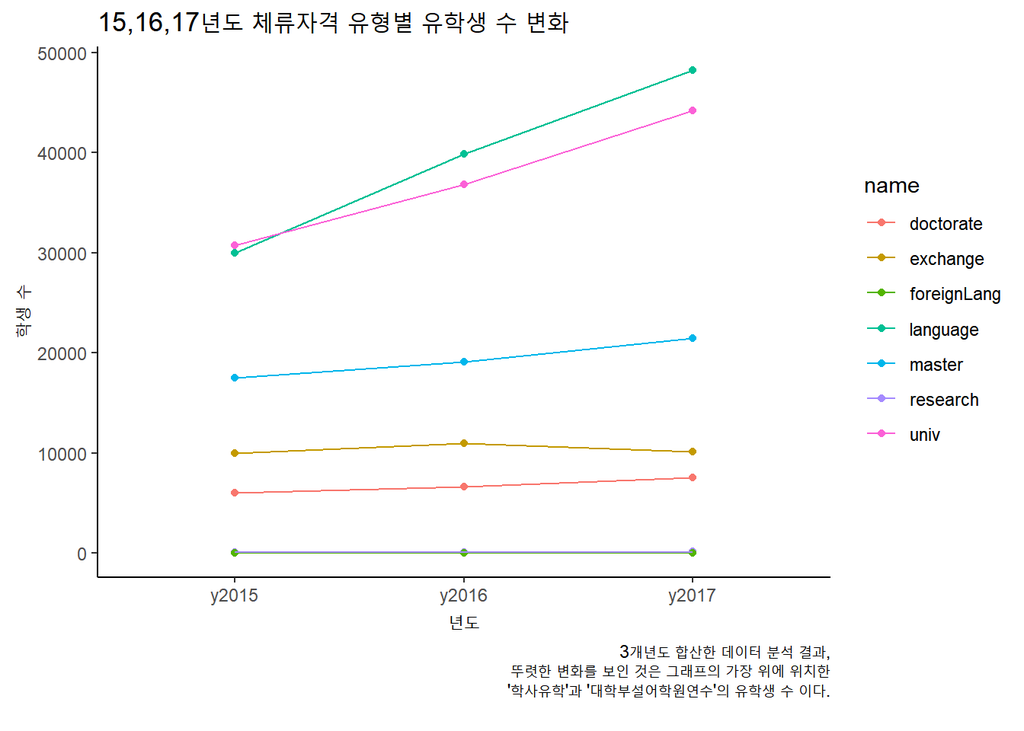

```r
library(ggplot2)

ggplot(year3, aes(x=key, y=value, col=name, group=name)) + geom_point()+geom_line()+ labs(title = '15,16,17년도 체류자격 유형별 유학생 수 변화', x='년도', y='학생 수', caption="3개년도 합산한 데이터 분석 결과,
             뚜렷한 변화를 보인 것은 그래프의 가장 위에 위치한
             '학사유학'과 '대학부설어학원연수'의 유학생 수 이다.
             ") + theme_classic()
```

#### 교환학생의 수와 박사유학의 학생 수의 변화의 차이는 미미함.

#### 그래프를 통해 가장 눈에 띄는 점은 학사유학의 학생 수와 대학부설어학원연수의 학생 수가 해마다 급격하게 증가하는 추이를 보인다는 것

# **번외. 대학별로 유학생 수를 담고 있는 데이터에서 명지대학교 유학생 현황을 파악하기**

## 데이터 설명

#### - 사용할 데이터 : **법무부 2018년 상반기 국내 유학중인 외국인유학생 관련자료**

#### - 성별, 생년, 국적명, 체류자격, 학교명, 체류 시도, 체류 시군구 의 항목이 나와있는 데이터

#### - 이 데이터에서 가장 중점적으로 다룰 데이터는 “명지대학교” 학생의 데이터

#### 데이터 불러오기

```r
stu18 <- read.csv("법무부_2018년_상반기_국내_유학중인_외국인유학생_관련자료.csv")
head(stu18)
```

```
##   성별 생년       국적명           체류자격         학교명 체류지.시도
## 1   남 1998       베트남 대학부설어학원연수     인하대학교  인천광역시
## 2   남 1998       베트남 대학부설어학원연수 영남외국어대학    경상북도
## 3   남 1998       베트남 대학부설어학원연수 영남신학대학교    경상북도
## 4   남 1998   에티오피아           학사유학 한국과학기술원  대전광역시
## 5   남 1998 우즈베키스탄           학사유학     전남대학교  광주광역시
## 6   남 1998       베트남 대학부설어학원연수     창원대학교    경상남도
##   체류지.시군구
## 1      미추홀구
## 2        경산시
## 3        경산시
## 4        유성구
## 5          북구
## 6 창원시 의창구
```

```r
str(stu18)
```

```
## 'data.frame':    143701 obs. of  7 variables:
##  $ 성별         : Factor w/ 2 levels "남","여": 1 1 1 1 1 1 1 1 1 2 ...
##  $ 생년         : int  1998 1998 1998 1998 1998 1998 1998 1998 1998 1998 ...
##  $ 국적명       : Factor w/ 174 levels "가나","가봉",..: 58 58 58 100 112 58 58 58 58 126 ...
##  $ 체류자격     : Factor w/ 8 levels "교환학생","대학부설어학원연수",..: 2 2 2 8 8 2 2 2 2 2 ...
##  $ 학교명       : Factor w/ 700 levels "(유)성보이엔지",..: 489 445 444 615 495 558 468 626 499 545 ...
##  $ 체류지.시도  : Factor w/ 18 levels "강원도","경기도",..: 13 4 4 7 5 3 15 2 15 2 ...
##  $ 체류지.시군구: Factor w/ 186 levels " ","가평군","강남구",..: 67 11 11 134 74 158 140 100 142 105 ...
```

#### 변수명 변경하기

```r
library(dplyr)
stu018 <- rename(stu18,
                 gender = '성별',
                 age = '생년',
                 nation = '국적명',
                 visa = '체류자격',
                 univName = '학교명',
                 sido = '체류지.시도',
                 sigungu = '체류지.시군구')
```

#### 데이터 파악하기

```r
head(stu018)
```

```
##   gender  age       nation               visa       univName       sido
## 1     남 1998       베트남 대학부설어학원연수     인하대학교 인천광역시
## 2     남 1998       베트남 대학부설어학원연수 영남외국어대학   경상북도
## 3     남 1998       베트남 대학부설어학원연수 영남신학대학교   경상북도
## 4     남 1998   에티오피아           학사유학 한국과학기술원 대전광역시
## 5     남 1998 우즈베키스탄           학사유학     전남대학교 광주광역시
## 6     남 1998       베트남 대학부설어학원연수     창원대학교   경상남도
##         sigungu
## 1      미추홀구
## 2        경산시
## 3        경산시
## 4        유성구
## 5          북구
## 6 창원시 의창구
```

```r
str(stu018)
```

```
## 'data.frame':    143701 obs. of  7 variables:
##  $ gender  : Factor w/ 2 levels "남","여": 1 1 1 1 1 1 1 1 1 2 ...
##  $ age     : int  1998 1998 1998 1998 1998 1998 1998 1998 1998 1998 ...
##  $ nation  : Factor w/ 174 levels "가나","가봉",..: 58 58 58 100 112 58 58 58 58 126 ...
##  $ visa    : Factor w/ 8 levels "교환학생","대학부설어학원연수",..: 2 2 2 8 8 2 2 2 2 2 ...
##  $ univName: Factor w/ 700 levels "(유)성보이엔지",..: 489 445 444 615 495 558 468 626 499 545 ...
##  $ sido    : Factor w/ 18 levels "강원도","경기도",..: 13 4 4 7 5 3 15 2 15 2 ...
##  $ sigungu : Factor w/ 186 levels " ","가평군","강남구",..: 67 11 11 134 74 158 140 100 142 105 ...
```

```r
summary(stu018)
```

```
##  gender          age                nation                      visa
##  남:65731   Min.   :1936   중국        :65327   대학부설어학원연수:52346
##  여:77970   1st Qu.:1993   베트남      :36575   학사유학          :47828
##             Median :1995   몽골        : 7952   석사유학          :22282
##             Mean   :1994   우즈베키스탄: 6252   교환학생          : 9403
##             3rd Qu.:1997   일본        : 2795   박사유학          : 8199
##             Max.   :2004   파키스탄    : 1619   전문학사          : 3482
##                            (Other)     :23181   (Other)           :  161
##          univName              sido           sigungu
##  미상        :  5221   서울특별시:50590   동대문구:  9089
##  고려대학교  :  4695   경기도    :18120   성북구  :  6701
##  성균관대학교:  4408   부산광역시:11824   서대문구:  5430
##  경희대학교  :  3720   경상북도  : 9314   남구    :  5230
##  건국대학교  :  3418   충청남도  : 6939   미상    :  4831
##  한양대학교  :  3287   전라북도  : 6650   광진구  :  4560
##  (Other)     :118952   (Other)   :40264   (Other) :107860
```

### 1) 2018 상반기에 어떤 국가의 유학생이 많은지 파악하기

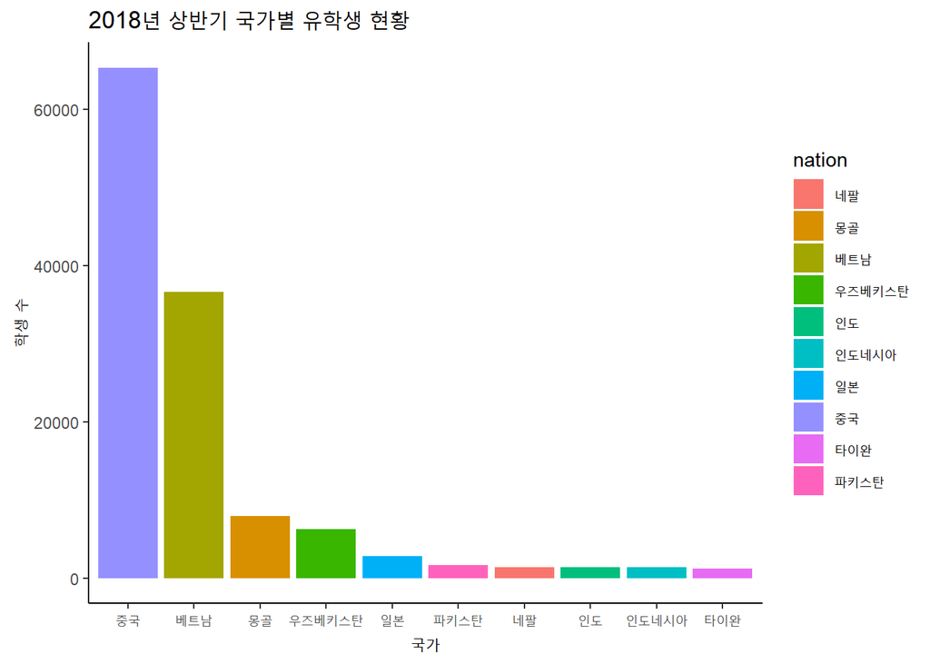

```r
library(dplyr)
library(ggplot2)

stu2018 <- stu018 %>%
  group_by(nation) %>%
  summarise(total = n()) %>%
  arrange(desc(total)) %>%
  head(10)

g <- ggplot(stu2018, aes(x = reorder(nation, desc(total)), y = total, fill=nation)) + geom_bar(stat="identity") + labs(title = '2018년 상반기 국가별 유학생 현황', x='국가', y='학생 수') + theme_classic()

g
```

#### 1순위: 중국, 2순위: 베트남, 3순위: 몽골 순으로 유학생 수가 많다.

### 2) 2018 상반기 유학생 중 어느 학교가 유학생이 많은지 파악하기

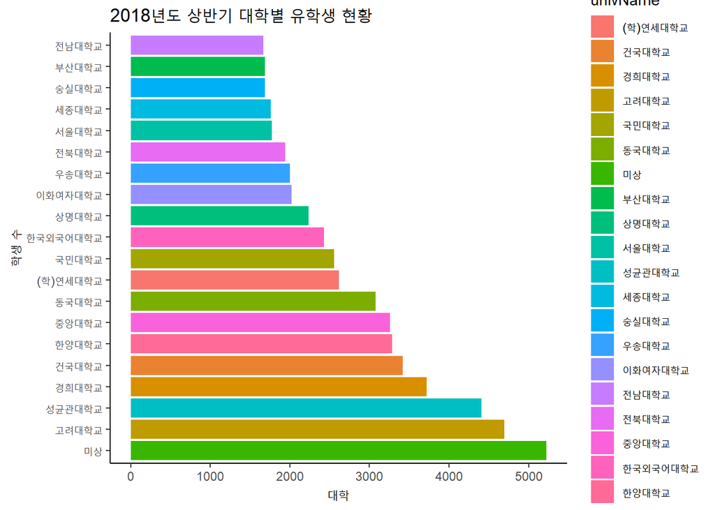

```r
library(dplyr)
library(ggplot2)

stu018.0 <- stu018 %>%
  group_by(univName) %>%
  summarise(total = n()) %>%
  arrange(desc(total)) %>%
  head(20)

g0 <- ggplot(stu018.0, aes(x = reorder(univName, desc(total)), y = total, fill = univName)) + geom_bar(stat = 'identity') + coord_flip() + labs(title = '2018년도 상반기 대학별 유학생 현황', x='학생 수', y='대학') + theme_classic()

g0
```

#### 학교 미상이 가장 많음

#### 미상을 제외하고, 1순위: 고려대, 2순위: 성균관대, 3순위: 경희대

#### 명지대학교는 상위 20개 중에 속하지 않음

### 3) 명지대학교에 유학온 유학생 중에 어떤나라의 유학생이 많은지 파악하기

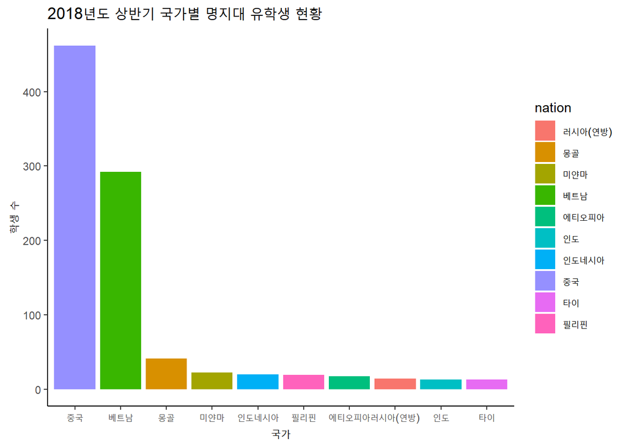

```r
library(dplyr)
library(ggplot2)

stu18.1 <- stu018 %>%
  select(nation, univName) %>%
  filter(univName == '명지대학교') %>%
  group_by(nation) %>%
  summarise(total = n()) %>%
  arrange(desc(total)) %>%
  head(10)

g1 <-  ggplot(stu18.1, aes(x = reorder(nation, desc(total)), y = total, fill=nation)) + geom_bar(stat="identity") + labs(title = '2018년도 상반기 국가별 명지대 유학생 현황', x='국가', y='학생 수') + theme_classic()

g1
```

#### 1순위: 중국, 2순위: 베트남, 3순위: 몽골

#### 이는 방금 위에서 살펴본 ’2018 상반기 어떤 국가의 유학생이 많은지’를 파악한 결과와 3순위까지 동일함

### 4) 명지대학교 유학생 중 어떤 유형의 비자로 유학온 학생이 많은지 파악하기

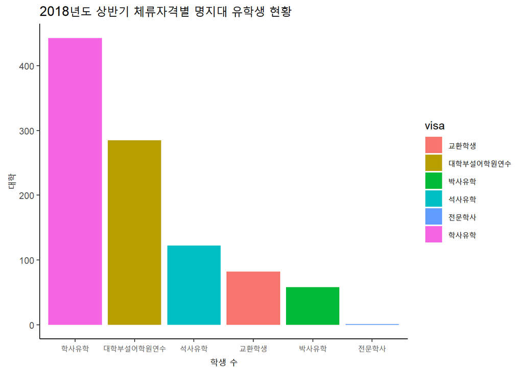

```r
library(dplyr)
library(ggplot2)

stu18.2 <- stu018 %>%
  select(visa, univName) %>%
  filter(univName == '명지대학교') %>%
  group_by(visa) %>%
  summarise(total = n()) %>%
  arrange(desc(total)) %>%
  head(10)

g2 <-  ggplot(stu18.2, aes(x = reorder(visa, desc(total)), y = total, fill=visa)) + geom_bar(stat="identity") + labs(title = '2018년도 상반기 체류자격별 명지대 유학생 현황', x='학생 수', y='대학') + theme_classic()

g2
```

#### 학사유학이 가장 많고, 그 다음으로는 대학부설 어학원 연수가 많은 것으로 나타남

# **결론**

#### 5. 3년치 데이터를 비교분석 했을 때, ’학사유학’과 ’대학부설어학원연수’의 자격을 가진 유학생의 수가 해마다 증가하는 추세를 보임

## [번외]

#### 6. 2018년 상반기 유학생은 중국 > 베트남 > 몽골 순으로 유학생이 많음

#### 7. 2018년 상반기 유학생이 많은 대학 상위 20위에는 명지대가 포함되어 있지 않음

#### 8. 명지대학교 유학생은 중국 > 베트남 > 몽골 순으로 유학생이 많음

#### 9. 명지대학교 유학생 중 학사유학 > 대학부설어학원연수 > 석사유학 순으로 유학생이 많음